# ETC5521 Diving Deeper into Data Exploration: Assignment 3

Author

HengHsieh Chang

Published

September 22, 2025

## Question 1: Assess the Published Reports

The three articles present contrasting views of Australian reading habits, particularly regarding gender differences and generational decline, all drawing from the 2020-21 ABS Time Use Survey but reaching markedly different conclusions.

Articles 1 (ABC News) and 2 (The Age) both argue that there is a crisis in men’s reading habits, particularly among the young. They build their case on the same key statistic from the Australian Bureau of Statistics (ABS): only 10.1% of males aged 15 to 24 read books regularly.

- Article 1 frames this as part of a wider gender gap, noting that older women are the most common group of readers (48%) and that parents are less likely to read to their sons, creating a social norm where reading isn’t seen as masculine.
- Article 2 attributes the decline to external factors, suggesting young men’s reading time has been replaced by podcasts, YouTube, and Reddit. It also blames a publishing industry that caters to an established female audience with “chick-lit,” which dominated the 2024 bestseller lists, creating a “torrid cycle of supply and demand” that excludes male readers.

Both articles use the raw numbers from the ABS survey to paint a picture of a severe, gender-specific decline.

However, Article 3 (The Guardian) effectively debunks this narrative by taking a more critical look at the data. It argues that claims of men “stopping reading” are an exaggeration based on a misinterpretation of the statistics.

The key points are:

- **Statistical Significance**: The article points out that once confidence intervals are applied to the ABS data, the apparent gaps between male and female reading rates are not statistically significant for most age groups. The only generation with a statistically significant difference is Gen X. This means the perceived “crisis” among young men is likely just statistical noise.
- **Long-Term Trends**: By incorporating historical data, the article shows that the decline in book reading is a long-term trend affecting both men and women. Book reading has been decreasing for everyone over the past decade, not just men.
- **Reading Format Preferences**: The analysis highlights that men and women simply read different things. While females are more frequent readers of books, males are more likely to frequently read news and magazines. This nuance is lost in the other reports.

**Article 3 provides the most appropriate and methodologically sound summary**. Instead of isolating one data point to create a sensational headline, it performs a more responsible analysis by:

- Applying statistical rigour to show that the gender differences are mostly insignificant.
- Providing historical context to demonstrate that the decline in reading is a broader, societal issue affecting everyone, not a new problem exclusive to young men.
- Acknowledging nuances in reading habits and format preferences between genders.

Therefore, the real story isn’t that men have stopped reading, but that frequent book reading has declined across the board for both genders, a conclusion that Articles 1 and 2 fail to capture accurately.

## Question 2

#### Subpart a: Questions

Based on the data `ABS_leisure_2022`, here are 3 substantial, answerable research questions I derived. These focus on generational and gender dynamics in leisure patterns,

- **1. Active vs. Passive Leisure Shifts Across Generations:**

How does the preference for active leisure activities (e.g., exercise/sport and outdoor activities) versus passive ones (e.g., watching TV/video and relaxing) change across generations, and at what generational turning point does passive leisure time begin to significantly exceed active leisure?

- **2. Intergenerational Gaps in Leisure Activities:**

Among recreation and leisure sub-activities, which shows the largest “generation gap” between younger cohorts (Gen Z) and older cohorts (Baby Boomers and Interwar, aged 55+), in both participation rates and average time spent per day? How do these gaps vary by gender?

- **3. Gender Gaps in Emerging vs. Traditional Leisure Activities:**

Do gender disparities appear wider in new leisure activities (such as digital gaming) among their primary users compared to traditional activities (such as reading) among their core demographics, suggesting that generational shifts may intensify gender differences in leisure preferences?

#### Subpart b: Initial Data Analysis (IDA)

Here is a summary of the data checking, cleaning, and preparation steps performed on the raw `ABS_leisure_2022.xlsx` file to make it suitable for analysis.

- **Raw Data Loading**: Imported the seven sheets from `ABS_leisure_2022.xlsx` as tibbles using `read_excel` with appropriate ranges to skip titles.

```r
library(readxl)
library(here)

# Raw Data Loading
leisure_2022_t1_raw <- read_excel(here("data", "ABS_leisure_2022.xlsx"),
                                  sheet = "Table 1.1", range = "A5:P24")

leisure_2022_t2_raw <- read_excel(here("data", "ABS_leisure_2022.xlsx"),
                                  sheet = "Table 1.2", range = "A5:P24")

leisure_2022_t3_raw <- read_excel(here("data", "ABS_leisure_2022.xlsx"),
                                  sheet = "Table 1.3", range = "A5:P24")

leisure_2022_t4_raw <- read_excel(here("data", "ABS_leisure_2022.xlsx"),
                                  sheet = "Table 1.4", range = "A5:P24")

leisure_2022_t5_raw <- read_excel(here("data", "ABS_leisure_2022.xlsx"),
                                  sheet = "Table 1.5", range = "A5:P24")

leisure_2022_t6_raw <- read_excel(here("data", "ABS_leisure_2022.xlsx"),
                                  sheet = "Table 1.6", range = "A5:P24")

leisure_2022_t7_raw <- read_excel(here("data", "ABS_leisure_2022.xlsx"),
                                  sheet = "Table 1.7", range = "A5:G15")
```

- **Metadata & Variable Understanding**: To ensure an accurate interpretation of the data, the official documentation from the Australian Bureau of Statistics (ABS) was consulted. This provided essential metadata and clear definitions for key variables, particularly for the categorization of recreation and leisure activities as detailed in the source article.
- **Data Screening**: An initial inspection revealed that all columns were read as text format due to footnotes and non-numeric characters within the data. This confirmed the need for significant data type conversion.

```r
library(dplyr)

# Data Structure Check
glimpse(leisure_2022_t1_raw)
glimpse(leisure_2022_t2_raw)
glimpse(leisure_2022_t3_raw)
glimpse(leisure_2022_t4_raw)
glimpse(leisure_2022_t5_raw)
glimpse(leisure_2022_t6_raw)
glimpse(leisure_2022_t7_raw)
```

- **Data Clean**
  - **Header Cleaning**: Cleaned headers by merging multi-row levels and stripping ages/spaces using custom function; filtered note rows.
  - **Data Type Conversion - Time**: The time values in Tables 1.3 and 1.5, originally in text format (“hh:mm”), were converted to numerical values by `lubridate::hm()` to represent total minutes (e.g., “1:55” → 115) that enable mathematical operations such as calculating averages and differences.
  - **Data Type Conversion - Percentages**: The participation rates in Table 1.1, originally in text format, were converted to numeric values and divided by 100 to be represented as decimal proportions (e.g., 97.2 becomes 0.972)

```r
library(stringr)
library(janitor)

#Create Data cleaning function
clean_abs_table <- function(file, sheet, range = NULL) {
  df <- read_excel(file, sheet = sheet, range = range, col_names = FALSE)

  # Extract first 2 rows as header
  header1 <- as.character(df[1, ])
  header2 <- as.character(df[2, ])

  # Fill left for generations
  for (i in seq_along(header2)) {
    if (!is.na(header2[i]) & header2[i] %in% c("Females", "Persons")) {
      j <- i - 1
      while (j > 0 && is.na(header1[j])) j <- j - 1
      if (j > 0) header1[i] <- header1[j]
    }
  }

  headers <- ifelse(is.na(header2), header1, paste(header1, header2, sep = "_"))

  #Remove unnecessary info
  headers <- headers |>
    str_remove("\\s*\\([^)]*\\)") |>
    str_replace_all("\\s+", "_") |>
    make_clean_names()

  # Remove header rows, apply new names
  df <- df[-c(1:2), ]
  names(df) <- headers

  # Rename header rows
  colnames(df)[1] <- "activity"

  # Remove the notes and NA rows
  df <- df %>%
    filter(!str_detect(tolower(activity), "primary activity"))%>%
    filter(!if_all(everything(), is.na))

  # Remove first row ("Free time")
  df <- df[-1, ]

  return(df)
}

# Apply function to each table
file_path <- here::here("data", "ABS_leisure_2022.xlsx")

leisure_2022_t1 <- clean_abs_table(file_path, sheet = "Table 1.1", range = "A5:P24")
leisure_2022_t2 <- clean_abs_table(file_path, sheet = "Table 1.2", range = "A5:P24")
leisure_2022_t3 <- clean_abs_table(file_path, sheet = "Table 1.3", range = "A5:P24")
leisure_2022_t4 <- clean_abs_table(file_path, sheet = "Table 1.4", range = "A5:P24")
leisure_2022_t5 <- clean_abs_table(file_path, sheet = "Table 1.5", range = "A5:P24")
leisure_2022_t6 <- clean_abs_table(file_path, sheet = "Table 1.6", range = "A5:P24")


# Clean table 7
leisure_2022_t7 <- leisure_2022_t7_raw %>%
  filter(!str_detect(...1, "PROPORTION OF TOTAL POPULATION"),
           !if_all(everything(), ~ is.na(.))) %>%
   mutate(
    survey_year = case_when(
      str_detect(...1, "2020-21 Time Use Survey") ~ "2020-21 Time Use Survey",
      str_detect(...1, "2021 Census") ~ "2021 Census",
      TRUE ~ NA_character_
    ))%>%
  rename_with(~ str_replace_all(., "\\s*\\r\\n.*", "") %>%
              make_clean_names())


leisure_2022_t7 <- leisure_2022_t7 %>% tidyr::fill(survey_year)
```

```r
library(lubridate)

# Time Conversion
time_to_min <- function(df) {
  time_cols <- df %>%
    select(where(~ any(str_detect(., "^\\d{1,2}:\\d{2}$"), na.rm = TRUE))) %>%
    colnames()

  if (length(time_cols) == 0) return(df)

  # Convert to minutes
  df <- df %>%
    mutate(across(all_of(time_cols), ~ period_to_seconds(hm(.)) / 60))

  return(df)
}

leisure_2022_t3 <- time_to_min(leisure_2022_t3)
leisure_2022_t5 <- time_to_min(leisure_2022_t5)
```

```r
# Props to decimals (t1)
leisure_2022_t1 <- leisure_2022_t1 %>%
  mutate(across(-activity, ~ as.numeric(.)/100))


# Convert RSE/margins value to numeric, then round to 1 demical (t2, t4, t6)
leisure_2022_t2 <- leisure_2022_t2 %>% mutate(across(-activity, as.numeric))%>%
    mutate(across(-activity, ~ round(., 1)))

leisure_2022_t4 <- leisure_2022_t4 %>% mutate(across(-activity, as.numeric))%>%
    mutate(across(-activity, ~ round(., 1)))

leisure_2022_t6 <- leisure_2022_t6 %>% mutate(across(-activity, as.numeric))%>%
    mutate(across(-activity, ~ round(., 1)))
```

- **Data Reshaping(Tidying)**: The original “wide” format tables were transformed into a **“long” tidy format**. This involved pivoting columns for different generations and genders into key-value pairs, creating distinct generation and gender variables. This structure is far more efficient for grouped analysis and visualization.

```r
library(tidyr)

# Pivot to long format
tidy_table <- function(df, value_name) {
  df %>%
    pivot_longer(-activity,
                 names_to = "group",
                 values_to = value_name) %>%
    extract(group, into = c("generation", "gender"),
          regex = "(generation_z|millennials|generation_x|baby_boomers|interwar)_?(males|females|persons)?")%>%
    mutate(
      gender = recode(gender, persons = "total")
    )
}

# Add activity category
add_activity_category <- function(df) {
  df %>%
    mutate(
      category = case_when(
        # ---- Social and community interaction ----
        activity %in% c("Social and community interaction",
                        "Social interaction",
                        "Eating and drinking out",
                        "Religious or cultural practices",
                        "Travel associated with social and community interaction")
          ~ "Social and community interaction",

        # ---- Recreation and leisure ----
        activity %in% c("Recreation and leisure",
                        "Exercise, sport and outdoor activity",
                        "Reading",
                        "Playing games and puzzles",
                        "Digital games",
                        "Watching TV and video",
                        "Listening to music, radio, podcast",
                        "General internet and device use",
                        "Relaxing",
                        "Hobbies and arts",
                        "Travel associated with recreation and leisure")
          ~ "Recreation and leisure",

        # ---- Free time & Total ----
        activity == "Free time" ~ "Free time",
        activity == "Total activities" ~ "Total activities",

        TRUE ~ NA_character_
      )
    )%>%
    relocate(category, .before = activity)
}


t1_tidy <- tidy_table(leisure_2022_t1, "prop_participation")%>%
  add_activity_category()

t2_tidy <- tidy_table(leisure_2022_t2, "prop_margin_error")%>%
  add_activity_category()

t3_tidy <- tidy_table(leisure_2022_t3, "time_participant_min")%>%
  add_activity_category()

t4_tidy <- tidy_table(leisure_2022_t4, "time_participant_rse")%>%
  add_activity_category()

t5_tidy <- tidy_table(leisure_2022_t5, "time_population_min")%>%
  add_activity_category()

t6_tidy <- tidy_table(leisure_2022_t6, "time_population_rse")%>%
  add_activity_category()

# Pivot table 7 to long
t7_tidy <- leisure_2022_t7 %>%
  slice(2:4, 6:8) %>%
  mutate(across(generation_z:interwar, as.numeric)) %>%
  pivot_longer(
    cols = generation_z:interwar,
    names_to = "generation",
    values_to = "prop_population"
  ) %>%
  rename(gender = x1) %>%
  mutate(
    gender = case_when(
      str_to_lower(gender) == "persons" ~ "total",
      TRUE ~ str_to_lower(gender)
    )
  ) %>%
  select(generation, gender, prop_population, survey_year)
```

- **Handling Missing Values**: Checked the cleaned data for missing values (NA). These were only found in activities with very few participants where the sample size was likely too small to calculate a reliable number. Since our analysis focuses on more common activities with complete data, these few missing values will not affect our final conclusions.

```r
data_list <- list(
  t1_tidy = t1_tidy,
  t2_tidy = t2_tidy,
  t3_tidy = t3_tidy,
  t4_tidy = t4_tidy,
  t5_tidy = t5_tidy,
  t6_tidy = t6_tidy
)

sapply(data_list, anyNA)

t6_tidy %>%
  filter(if_any(everything(), is.na))
```

- **Reliability Integration**: To ensure statistical validity, a flag column was added to identify and classify the reliability of data points based on their Relative Standard Error (RSE). Estimates with an RSE between 25-50% are flagged for “Caution,” and those above 50% are flagged as “Unreliable,” preventing misinterpretation of statistically uncertain figures..

```r
rse_flag <- function(df, rse_col) {
  df %>%
    mutate(
      flag = case_when(
        is.na({{rse_col}}) ~ "Unreliable(>50%)",
        {{rse_col}} > 50 ~ "Unreliable(>50%)",
        {{rse_col}} > 25 ~ "Caution(25-50%)",
        TRUE ~ "Reliable(≤25%)"
        )
      )
}

t4_tidy <- rse_flag(t4_tidy, time_participant_rse)
t6_tidy <- rse_flag(t6_tidy, time_population_rse)
```

- **Data Integration**: The six cleaned and tidied tables (Tables 1.1 to 1.6) were merged into a single, comprehensive data frame. This master table consolidates all relevant metrics—participation rates, margins of error, and time spent—into one analysis-ready dataset.

```r
# Integration to one major table
clean_leisure_2022 <- t1_tidy %>%
  full_join(t2_tidy, by = c("category", "activity", "generation", "gender")) %>%
  full_join(t3_tidy, by = c("category", "activity", "generation", "gender")) %>%
  full_join(t4_tidy, by = c("category", "activity", "generation", "gender")) %>%
  full_join(t5_tidy, by = c("category", "activity", "generation", "gender")) %>%
  full_join(t6_tidy, by = c("category", "activity", "generation", "gender"))
```

- **Final Output**: The fully cleaned and processed data has been saved to a CSV file named `ABS_leisure_2022_cleaned.csv`. This file is now ready for the analytical and visualization tasks required to answer the three research questions.

```r
library(readr)
write_csv(clean_leisure_2022, "data/ABS_leisure_2022_cleaned.csv")
```

#### Subpart c: Analysis to Address Questions

##### 1. Active vs. Passive Leisure Shifts Across Generations

To see how leisure patterns change across generations, we first grouped “Recreation and leisure” activities into two main types:

- Active Leisure: Includes physical activities like “Exercise, sport and outdoor activity.”
- Passive Leisure: Includes non-physical activities like “Watching TV and video” and “Reading.”

To make a fair comparison, we analyzed the average time spent across the entire population, not just the time spent by participants. The error bars on the charts show the statistical margin of error, helping to visualize the data’s reliability.

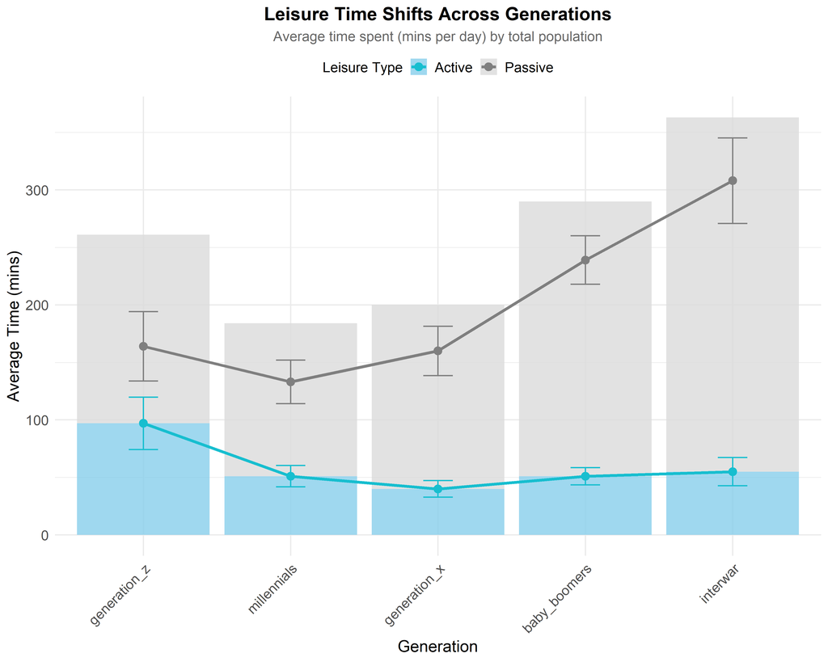

```r
library(tidyverse)
library(dplyr)
library(ggplot2)

# Define active vs passive activities
active_acts <- c(
  "Exercise, sport and outdoor activity",
  "Playing games and puzzles",
  "Digital games",
  "Hobbies and arts",
  "Travel associated with recreation and leisure"
)

passive_acts <- c(
  "Reading",
  "Watching TV and video",
  "Listening to music, radio, podcast",
  "General internet and device use",
  "Relaxing"
)


p1 <- clean_leisure_2022 %>%
  filter(activity %in% c(active_acts, passive_acts), gender == "total",
         flag.y != "Unreliable(>50%)" )%>%
  mutate(type = case_when(
    activity %in% active_acts ~ "Active",
    activity %in% passive_acts ~ "Passive",
  )) %>%
  group_by(generation, type) %>%
  summarise(
    act_min = sum(time_population_min, na.rm = TRUE),
    rse = mean(time_population_rse, na.rm = TRUE),
    .groups = "drop"
  ) %>%
  mutate(se = act_min * (rse / 100) / 1.96,
         ci_low = act_min - (se * 1.96),
         ci_high = act_min + (se * 1.96)) %>%
  mutate(generation = factor(generation,
                             levels = c("generation_z",
                                        "millennials",
                                        "generation_x",
                                        "baby_boomers",
                                        "interwar")))

# Plot for leisure time trend
ggplot(p1, aes(x = generation, y = act_min, group = type)) +
  geom_col(aes(fill = type), position = position_stack(reverse = TRUE), alpha = 0.8) +
  geom_line(aes(color = type), linewidth = 1.2) +
  geom_point(aes(color = type), size = 3) +
  geom_errorbar(aes(ymin = ci_low, ymax = ci_high, color = type), width = 0.2) +
  scale_fill_manual(
    name = "Leisure Type",
    values = c("Active" = "skyblue", "Passive" = "#dbdbdb")
  ) +
  scale_color_manual(
    name = "Leisure Type",
    values = c("Active" = "#17becf", "Passive" = "#7f7f7f")
  ) +
  labs(
    title = "Leisure Time Shifts Across Generations",
    subtitle = "Average time spent (mins per day) by total population",
    x = "Generation",
    y = "Average Time (mins)"
  ) +
  theme_minimal(base_size = 12) +
  theme(
    plot.title = element_text(hjust = 0.5, face = "bold", size = 16),
    plot.subtitle = element_text(hjust = 0.5, color = "gray40"),
    axis.title = element_text(size = 14),
    axis.text = element_text(size = 12),
    axis.text.x = element_text(angle = 45, hjust = 1),
    legend.text = element_text(size = 12),
    legend.position = "top"
  )
```

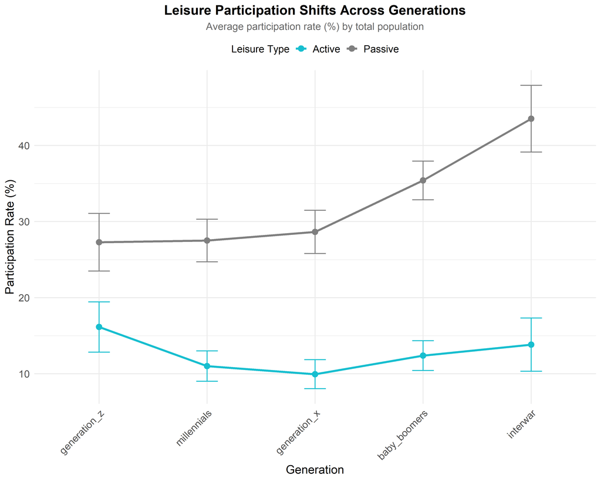

Figure 2: Average participation rate (%) in active vs. passive leisure activities, by generation. Data includes 95% confidence intervals represented by error bars.

```r
# Participation rate plot for preference
p2 <- clean_leisure_2022 %>%
  filter(activity %in% c(active_acts, passive_acts), gender == "total") %>%
  mutate(type = case_when(
    activity %in% active_acts ~ "Active",
    activity %in% passive_acts ~ "Passive",
  )) %>%
  group_by(generation, type) %>%
  summarise(prop = mean(prop_participation, na.rm = TRUE) * 100,
            margin = mean(prop_margin_error, na.rm = TRUE), .groups = "drop") %>%
  mutate(generation = factor(generation,
                             levels = c("generation_z",
                                        "millennials",
                                        "generation_x",
                                        "baby_boomers",
                                        "interwar")))

ggplot(p2, aes(x = generation, y = prop, color = type, group = type)) +
  geom_line(linewidth = 1.2) +
  geom_point(size = 3) +
  geom_errorbar(aes(ymin = prop - margin, ymax = prop + margin), width = 0.2) +
  labs(
    title = "Leisure Participation Shifts Across Generations",
    subtitle = "Average participation rate (%) by total population",
    y = "Participation Rate (%)",
    x = "Generation"
  ) +
  scale_color_manual(
    name = "Leisure Type",
    values = c("Active" = "#17becf", "Passive" = "#7f7f7f")
  ) +
  theme_minimal(base_size = 12) +
  theme(
    plot.title = element_text(hjust = 0.5, face = "bold", size = 16),
    plot.subtitle = element_text(hjust = 0.5, color = "gray40"),
    axis.title = element_text(size = 14),
    axis.text = element_text(size = 12),
    axis.text.x = element_text(angle = 45, hjust = 1),
    legend.text = element_text(size = 12),
    legend.position = "top"
  )
```

**Key Findings:**

From Figure 1, we observe several clear patterns in how different generations allocate their leisure time:

- **Dominance of Passive Leisure:** The total average time dedicated to passive leisure significantly exceeds that of active leisure across all generations. **There is no generational turning point** where one overtakes the other.However, if we consider the “turning point” as when the gap significantly widens, we see that before Gen X, the gap remains stable, but it grows significantly after that.
- **Increasing Passive Time:** A strong positive correlation exists between age and time spent in passive leisure. The average time increases dramatically from approximately 150 minutes per day for Gen Z to more than 300 minutes for the Interwar generation.
- **Stable Active Time:** In contrast, time spent on active leisure remains relatively stable. For most generations, it stays around 50 minutes per day, except for Gen Z, where it rises to about 100 minutes.
- **Widening Gap Between Active and Passive Leisure:** The most critical finding is the **growing gap between the time spent on passive and active leisure as generations age.**. This suggests that while active habits are maintained at a consistent level, passive activities consume a much larger portion of older Australians’ free time

And from Figure 2, we see:

- **Consistently Higher Passive Participation:** Contrary to a “turning point” hypothesis, the participation rate for passive leisure is consistently higher than for active leisure across all generations. The two trend lines do not cross.
- **Diverging Trends:** Active leisure starts at 15% for Gen Z, drops to 10% for Gen X, then rises slightly to 15% for the Interwar generation. This decline in Gen X (40-54 years) likely reflects their busy work and family lives. The slight recovery in older generations may be due to increased free time post-retirement.

Meanwhile, passive leisure steadily rises from 25% for Gen Z to nearly 45% for the Interwar generation, indicating a shift towards less physically demanding activities with age.

##### 2. Intergenerational Gaps in Leisure Activities

This analysis identifies the leisure activities with the biggest “generation gap.” We compared the youngest group, Gen Z (ages 15-24), against a combined group of older generations (Baby Boomers and Interwar, ages 55+).

To ensure our conclusions are sound, we excluded any data that was flagged as unreliable.

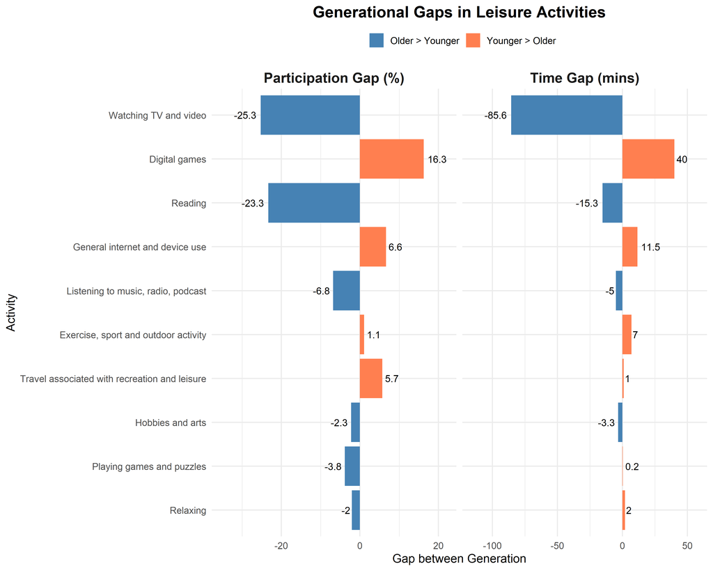

Figure 3

```r
p3 <- clean_leisure_2022 %>%
  filter(gender == "total",
         flag.y != "Unreliable(>50%)",
         category == "Recreation and leisure",
         activity != "Recreation and leisure",
         generation %in% c("generation_z", "baby_boomers", "interwar")
  ) %>%
  left_join(t7_tidy, by = c("generation", "gender")) %>%
  mutate(cohort = if_else(generation == "generation_z", "Young", "Old")
  ) %>%
  group_by(activity, cohort) %>%
  summarise(
    avg_prop = weighted.mean(prop_participation, w = prop_population, na.rm = TRUE) * 100,
    avg_time = weighted.mean(time_population_min,w = prop_population, na.rm = TRUE),
    .groups = "drop") %>%
  pivot_wider(
    names_from = cohort,
    values_from = c(avg_prop, avg_time)
  ) %>%
  mutate(
    `Participation Gap (%)` = avg_prop_Young - avg_prop_Old,
    `Time Gap (mins)` = avg_time_Young - avg_time_Old
  ) %>%
  pivot_longer(
    c(`Participation Gap (%)`, `Time Gap (mins)`),,
    names_to = "metric",
    values_to = "gap"
  )

ggplot(p3, aes(x = reorder(activity, abs(gap)), y = gap)) +
  geom_col(aes(fill = gap > 0))+
  geom_text(aes(label = round(gap, 1),
                hjust = ifelse(gap > 0, -0.2, 1.2)),
            size = 3.5) +
  coord_flip() +
  facet_wrap(~metric, scales = "free_x") +
  scale_y_continuous(expand = expansion(mult = c(0.3, 0.2))) +
  scale_fill_manual(
    name = "",
    labels = c("Older > Younger", "Younger > Older"),
    values = c("TRUE" = "coral", "FALSE" = "steelblue")
  ) +
  labs(
    title = "Generational Gaps in Leisure Activities",
    y = "Gap between Generation",
    x = "Activity"
  ) +
  theme_minimal(base_size = 12)+
  theme(
    strip.text = element_text(size = 14, face = "bold"),
    plot.title = element_text(hjust = 0.5, face = "bold", size = 16),
    plot.subtitle = element_text(hjust = 0.5, color = "gray40"),
    legend.position = "top"
  )
```

As Figure 3 shown, these differences are most pronounced in activities related to digital technology and traditional media consumption. The gap is defined as the value for the younger cohort (aged 15-24) minus the value for the older cohort (aged 55+), meaning positive values indicate activities more popular with the young, and negative values indicate those more popular with the old.

The key findings are as follows:

**1. Older Cohort Dominates Traditional Leisure:**

The largest generational gaps are found in traditional activities led by the older cohort (55+).

- **Time Gap**: The most extreme gap is in time spent **“Watching TV and video”**, where the older cohort averages 85.6 minutes more per day than the younger cohort.
- **Participation Gap**`: **“Reading” and “Watching TV and video”** shows the largest gap of participation rate among the older cohort with 23.3% and 25.3% points higher respectively.

**2. Younger Cohort Dominates Digital Entertainment:** The younger cohort (15-24) shows significantly higher engagement in all digital activities.

- The most significant gap is in **“Digital games”**, where the younger cohort’s participation is 16% points higher, and they spend 40 minutes more per day on this activity.
- The second-largest gap is also a digital activity: General internet and device use. Here, the participation rate for the young is approximately 6.6% points higher.
- Additionally, the younger cohort shows a higher, though smaller, engagement in **“Exercise, sport and outdoor activity”** compared to the older cohort.

In conclusion, the data points to a clear generational divide in leisure preferences, largely defined by technology. Younger Australians have integrated interactive digital entertainment into their daily lives, while older Australians continue to dedicate a significant amount of time to traditional, passive media and hobbies like reading.

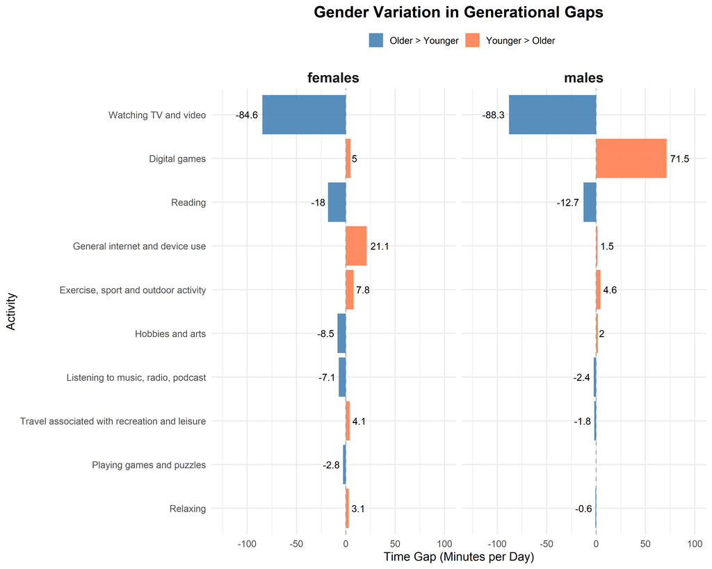

Figure 4

```r
# Gender variation (example for top gaps)
p4 <- clean_leisure_2022 %>%
  filter(gender != "total",
         flag.y != "Unreliable(>50%)",
         category == "Recreation and leisure",
         activity != "Recreation and leisure",
         generation %in% c("generation_z", "baby_boomers", "interwar")
  ) %>%
  left_join(t7_tidy, by = c("generation", "gender")) %>%
  mutate(cohort = if_else(generation == "generation_z", "Young", "Old")
  ) %>%
  group_by(activity, gender, cohort) %>%
  summarise(
    avg_time = weighted.mean(time_population_min,  w = prop_population, na.rm = TRUE),
    .groups = "drop"
  ) %>%
  group_by(activity, gender) %>%
  summarise(
    avg_time_Young = first(avg_time[cohort == "Young"]),
    avg_time_Old = first(avg_time[cohort == "Old"]),
    .groups = "drop"
  ) %>%
  mutate(
    gap_time = avg_time_Young - avg_time_Old
  ) %>%
  group_by(activity) %>%
  mutate(avg_abs_gap = mean(abs(gap_time), na.rm = TRUE)) %>%
  ungroup()


ggplot(p4, aes(x = gap_time, y = reorder(activity, avg_abs_gap))) +
  geom_vline(xintercept = 0, linetype = "dashed", color = "gray70") +
  geom_col(aes(fill = gap_time > 0), alpha = 0.9) +
  geom_text(aes(label = round(gap_time, 1),
                hjust = if_else(gap_time >= 0, -0.2, 1.2)),
            size = 3.5) +
  facet_wrap(~gender, ncol = 2) +
  scale_fill_manual(
    name = "",
    labels = c("Older > Younger", "Younger > Older"),
    values = c("TRUE" = "coral", "FALSE" = "steelblue"),
    na.translate = FALSE
  ) +
  labs(
    title = "Gender Variation in Generational Gaps",
    x = "Time Gap (Minutes per Day)",
    y = "Activity"
  ) +
  scale_x_continuous(expand = expansion(mult = c(0.3, 0.25))) +
  theme_minimal(base_size = 12) +
  theme(
    strip.text = element_text(size = 14, face = "bold"),
    plot.title = element_text(hjust = 0.5, face = "bold", size = 16),
    plot.subtitle = element_text(hjust = 0.5, color = "gray40"),
    legend.position = "top"
  )
```

While the general trend of younger cohorts preferring digital activities and older cohorts preferring traditional ones applies to both genders, the Figure 4 shows that the size of the generation gap often differs significantly between men and women for specific activities.

- **Gap in Digital Games is Primarily Driven by Males:** This is the most significant gender difference. Younger males spend an average of 71.5 minutes more per day on Digital games than older males. However, this gap is **only 5 minutes for females**. This shows that the generation gap in digital gaming is overwhelmingly a male phenomenon.
- **Impact of Traditional Media is Consistent Across Genders:** The large time gap in Watching TV and video affects both sexes almost equally. Older males spend 88.3 minutes more than younger males, and the gap for females is also very large at 84.6 minutes. This suggests that the appeal of traditional television to older cohorts is universal, regardless of gender.
- Other Gaps Show Distinct Gender Patterns:
  - While the gap in **“Reading”** is large for both genders, it is slightly more pronounced among females (-18) compared to males (-12.7).
  - The pattern for **“Hobbies and arts”** is completely different for men and women. For females, the older generation spends 8.5 minutes more on these activities than the younger generation. For males, however, the trend is slightly reversed, with the younger generation spending 2 minute more. This suggests the generational shift towards traditional hobbies is a trend primarily seen in women.
  - The gap in General internet and device use is larger for young females (+21.1) than for young males (+1.5).

In conclusion, Figure 3 and Figure 4 not only confirms the existence of generation gaps but further reveals how these gaps are shaped and modified by gender.

*Note on Data Uncertainty: As exact error margins for differences are complex to calculate, it’s more practical to focus on the size of the gaps. These results are based on sample survey data and carry some uncertainty. Large gaps are likely meaningful, but smaller gaps should be interpreted with caution due to possible sampling variation.*

##### 3. Gender Gaps in Emerging vs. Traditional Leisure Activities:**

This section explores gender differences in leisure and how they change across generations. We defined two categories of activities:

- Emerging Leisure: Modern, digital activities like “Digital games” and “General internet and device use.”
- Traditional Leisure: Classic, non-digital activities like “Reading” and “Hobbies and arts.”

We then compared the participation rates and average time spent by males and females in these categories across all generations. The goal was to identify which activities show the largest gender gaps and whether those gaps widen or narrow with age.

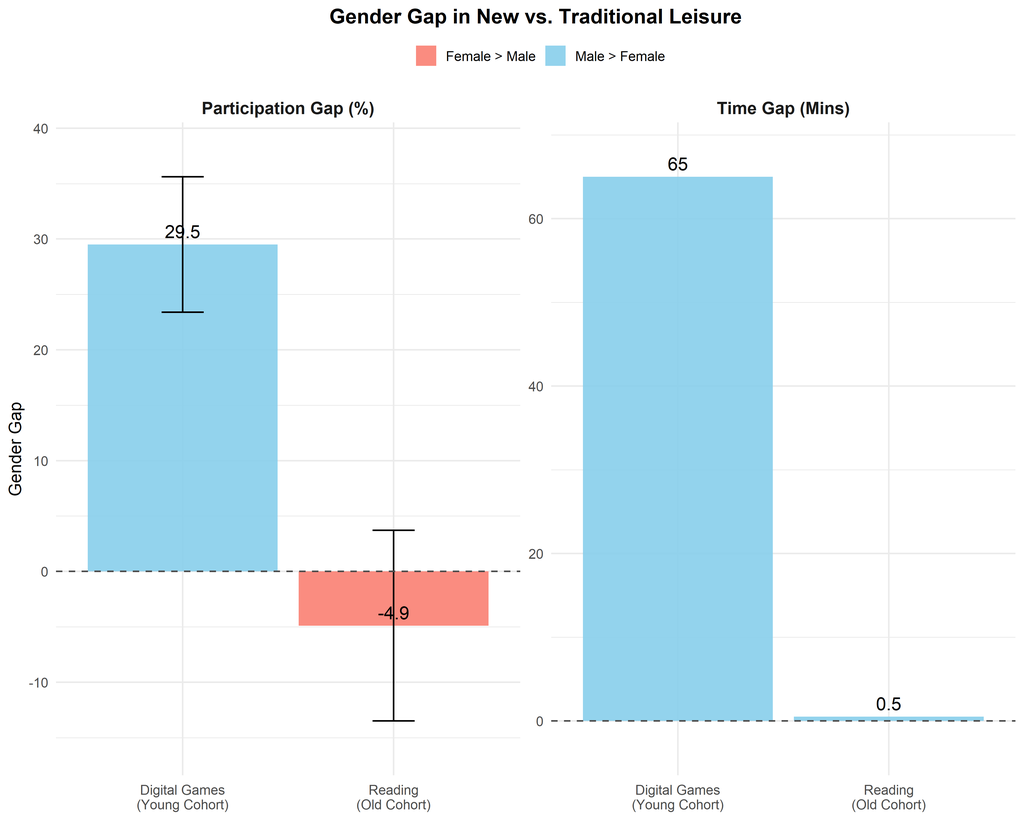

Figure 5

```r
digital_games_gap <- clean_leisure_2022 %>%
  filter(activity == "Digital games",
         generation == "generation_z",
         gender != "total",
         flag.y != "Unreliable(>50%)")%>%
  mutate(se_prop = (prop_margin_error / 1.96)) %>%
  pivot_wider(id_cols = activity,
              names_from = gender,
              values_from = c(prop_participation, time_population_min, se_prop)) %>%
  mutate(
    Participation_Gap = (prop_participation_males - prop_participation_females) * 100,
    Time_Gap = time_population_min_males - time_population_min_females,
    se_prop_gap = sqrt(se_prop_males^2 + se_prop_females^2),
    margin_prop_gap = se_prop_gap * 1.96
  ) %>%
  select(
    Activity_Group = activity,
    Participation_Gap,
    Time_Gap,
    margin_prop_gap
  ) %>%
  mutate(Activity_Group = "Digital Games\n(Young Cohort)")


reading_gap <- clean_leisure_2022 %>%
  filter(activity == "Reading",
         generation %in% c("baby_boomers", "interwar"),
         gender != "total",
         flag.y != "Unreliable(>50%)") %>%
  mutate(se_prop = (prop_margin_error / 1.96)) %>%
  group_by(gender) %>%
  summarise(
    Avg_Participation = mean(prop_participation, na.rm = TRUE),
    Avg_Time = mean(time_population_min, na.rm = TRUE),
    Avg_se_prop = sqrt(mean(se_prop^2, na.rm = TRUE))
  ) %>%
  pivot_wider(names_from = gender,
              values_from = c(Avg_Participation,
                              Avg_Time,
                              Avg_se_prop)) %>%
  mutate(
    Participation_Gap = (Avg_Participation_males - Avg_Participation_females) * 100,
    Time_Gap = (Avg_Time_males - Avg_Time_females),
    se_prop_gap = sqrt(Avg_se_prop_males^2 + Avg_se_prop_females^2),
    margin_prop_gap = se_prop_gap * 1.96
  ) %>%
  select(
    Participation_Gap,
    Time_Gap,
    margin_prop_gap
  ) %>%
  mutate(Activity_Group = "Reading\n(Old Cohort)")


p5 <- bind_rows(digital_games_gap, reading_gap) %>%
  pivot_longer(cols = c(Participation_Gap, Time_Gap),
               names_to = "Metric",
               values_to = "Gap") %>%
  mutate(
    Margin_Error = if_else(Metric == "Participation_Gap",
                           margin_prop_gap, NA_real_),
    Metric = recode(Metric,
                    "Participation_Gap" = "Participation Gap (%)",
                    "Time_Gap" = "Time Gap (Mins)")
  )

ggplot(p5, aes(x = Activity_Group, y = Gap)) +
  geom_col(aes(fill = Gap > 0), show.legend = TRUE, alpha = 0.9) +
  geom_errorbar(aes(ymin = Gap - Margin_Error, ymax = Gap + Margin_Error), width = 0.2) +
  geom_text(aes(label = round(Gap, 1)), vjust = -0.5, size = 4.5) +
  geom_hline(yintercept = 0, linetype = "dashed", color = "gray30") +
  facet_wrap(~Metric, scales = "free_y") +
  scale_y_continuous(expand = expansion(mult = c(0.1, 0.1)))+
  labs(
    title = "Gender Gap in New vs. Traditional Leisure",
    x = NULL,
    y = "Gender Gap",
    fill = "Gap Direction"
  ) +
  scale_fill_manual(
    name = "",
    labels = c("Female > Male", "Male > Female"),
    values = c("TRUE" = "skyblue", "FALSE" = "salmon")
  ) +
  theme_minimal(base_size = 12) +
  theme(
    plot.title = element_text(hjust = 0.5, face = "bold"),
    plot.subtitle = element_text(hjust = 0.5, color = "gray40"),
    strip.text = element_text(face = "bold", size = 12),
    axis.text.x = element_text(vjust = 0.5),
    legend.position = "top"
  )
```

Figure 5 compares the gender gap within the core user groups of an emerging leisure activity (Digital Games) versus a traditional one (Reading). The gap is calculated as (Male value - Female value), so positive values mean the male rate is higher, and negative values mean the female rate is higher.

- **Large Gender Gap in New Leisure:** In the emerging activity, Digital Games, the gender gap among its core users (the young cohort) is extremely large. As the chart shows, the participation rate for **males is 29.5% points higher than for females**, and they spend **65 minutes more** per day on this activity. The error bars indicate this gap is statistically significant.
- **Minimal Gender Gap in Traditional Leisure:** In contrast, for the traditional activity, Reading, the gender gap among its core users (the older cohort) is minimal. The female participation rate is **only 4.9% points higher** than the male rate, while males spend just 0.5 minutes more per day. The error bars cross the zero line, which suggests these small differences are not statistically significant.

In conclusion, the finding is clear: the gender disparity is dramatically wider in the new leisure activity (Digital Games) compared to the traditional one (Reading). This supports the hypothesis that the generational shift in leisure preferences may be intensifying differences between genders.

## Question 3: Comparison with 2006, 1997 and 1992 data

#### Introduction

This analysis focus on how Australians spent their time in 1992, 1997, and 2006. It uses data from ABS surveys. We focus on major activities like personal care, work, home tasks, child care, and leisure. The report covers two plots and two tables. It shows trends by gender and day type (weekday or weekend). Key changes include more time on personal care and leisure, less on social activities, and some gender differences.

#### Data Preparation

```r
library(patchwork)

time_to_min <- function(df) {
  time_cols <- df %>%
    select(where(~ any(str_detect(., "^\\d{1,2}:\\d{2}$"), na.rm = TRUE))) %>%
    colnames()
  if (length(time_cols) == 0) return(df)
  # Convert to minutes
  df <- df %>%
    mutate(across(all_of(time_cols), ~ period_to_seconds(hm(.)) / 60))
  return(df)
}

# Function to read and process Table 1
process_table1 <- function(file_path) {
  data <- read_excel(file_path, sheet = "Table 1", skip = 6)
  colnames(data) <- c("Activity", "M1992", "F1992", "P1992", "M1997", "F1997", "P1997", "M2006", "F2006", "P2006")

  # Convert time columns to minutes
  data <- time_to_min(data)

  # Filter relevant activities
  data <- data %>%
    filter(!Activity %in% c("All activities", "Undescribed", NA, "")) %>%
    pivot_longer(cols = -Activity,
                 names_to = "Gender_Year",
                 values_to = "Time_Minutes") %>%
    separate(Gender_Year,
             into = c("Gender", "Year"),
             sep = 1) %>%
    mutate(Year = as.integer(Year))

  # Group major categories
  major_categories <- c("Personal care",
                        "Employment related",
                        "Education",
                        "Domestic activities",
                        "Child care",
                        "Purchasing goods and services",
                        "Voluntary work and care",
                        "Social and community interaction",
                        "Recreation and leisure")

  data <- data %>%
    filter(Activity %in% major_categories) %>%
    mutate(Gender = recode(Gender, "M" = "Males", "F" = "Females", "P" = "Total"))

  return(data)
}

# Function to read and process Table 2
process_table2 <- function(file_path) {
  data <- read_excel(file_path, sheet = "Table 2", skip = 6)
  colnames(data) <- c("Activity", "M1992_WD", "F1992_WD", "M1997_WD", "F1997_WD", "M2006_WD", "F2006_WD", "M1992_WE", "F1992_WE", "M1997_WE", "F1997_WE", "M2006_WE", "F2006_WE")

  # Convert time columns to minutes
  data <- time_to_min(data)

  # Filter relevant activities
  data <- data %>%
    filter(!Activity %in% c("Total activities", NA, "")) %>%
    pivot_longer(cols = -Activity,
                 names_to = "Gender_Year_Day",
                 values_to = "Time_Minutes") %>%
    separate(Gender_Year_Day,
             into = c("Gender", "Year", "DayType"),
             sep = c(1, 5)) %>%
    mutate(Year = as.integer(Year),
           DayType = recode(DayType, "_WD" = "Weekday", "_WE" = "Weekend"))

  # Filter major categories
  major_categories <- c("Personal care",
                        "Employment related",
                        "Education",
                        "Domestic activities",
                        "Child care",
                        "Purchasing goods and services",
                        "Voluntary work and care",
                        "Social and Community interaction",
                        "Recreation and leisure")

  data <- data %>%
    filter(Activity %in% major_categories) %>%
    mutate(Gender = recode(Gender, "M" = "Males", "F" = "Females"))

  return(data)
}

# Load data using here for path
file_path <- here("data","ABS_leisure_historic.xlsx")
table1_data <- process_table1(file_path)
table2_data <- process_table2(file_path)
```

**1. Australians’ Time use Changes from 1992, 1997, 2006**

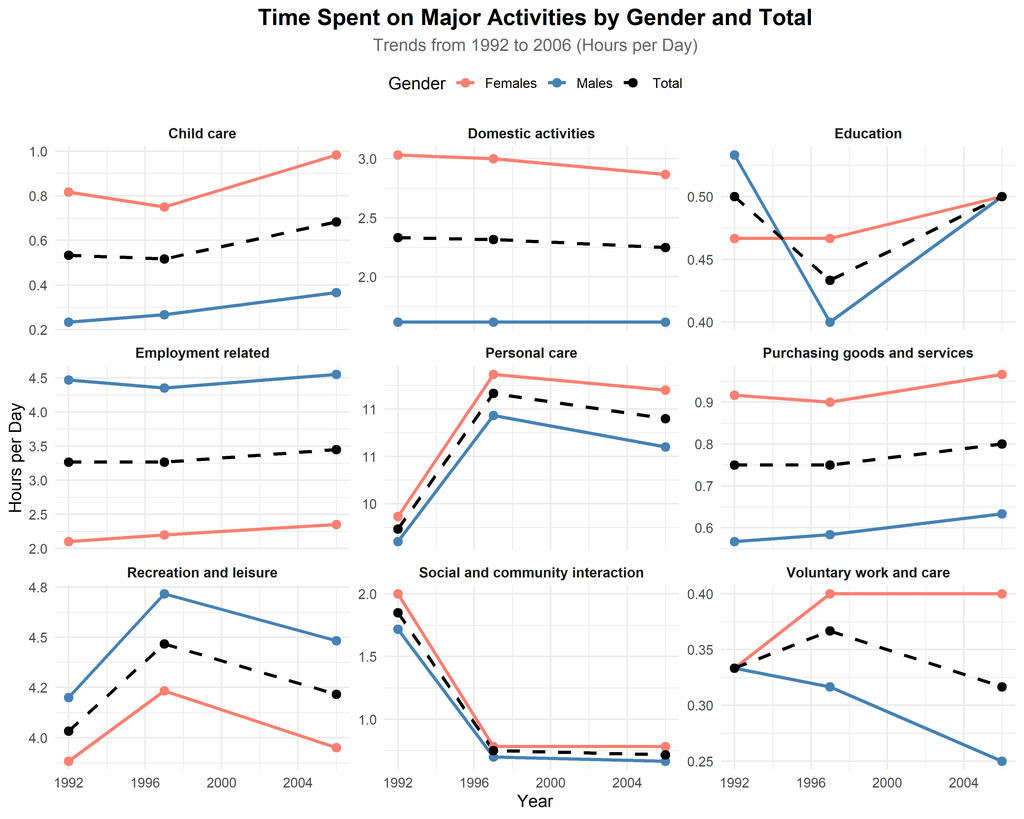

Figure 6

```r
ggplot(table1_data, aes(x = Year,
                        y = Time_Minutes / 60,
                        color = Gender,
                        group = Gender)) +
  geom_line(aes(linetype = Gender), linewidth = 1.1) +
  geom_point(size = 2.5) +
  facet_wrap(~ Activity, scales = "free_y", ncol = 3) +
  scale_color_manual(values = c("Males" = "steelblue",
                                "Females" = "salmon",
                                "Total" = "black")) +
  scale_linetype_manual(values = c("Males" = "solid",
                                   "Females" = "solid",
                                   "Total" = "dashed")) +
  labs(
    title = "Time Spent on Major Activities by Gender and Total",
    subtitle = "Trends from 1992 to 2006 (Hours per Day)",
    x = "Year",
    y = "Hours per Day",
    color = "Gender",
    linetype = "Gender"
  ) +
  theme_minimal(base_size = 12) +
  theme(
    plot.title = element_text(hjust = 0.5, face = "bold", size = 16),
    plot.subtitle = element_text(hjust = 0.5, color = "gray40"),
    strip.text = element_text(face = "bold", size = 10),
    legend.position = "top"
  )
```

```r
library(kableExtra)
changes <- table1_data %>%
  filter(Gender == "Total") %>%
  pivot_wider(names_from = Year, values_from = Time_Minutes, names_prefix = "Time_") %>%
  mutate(
    Time_1992_Hrs = round(Time_1992 / 60, 2),
    Time_1997_Hrs = round(Time_1997 / 60, 2),
    Time_2006_Hrs = round(Time_2006 / 60, 2),
    Change_92_97_Hrs = round(Time_1997_Hrs - Time_1992_Hrs, 2),
    Pct_Change_92_97 = round((Change_92_97_Hrs / Time_1992_Hrs) * 100, 2),
    Change_97_06_Hrs = round(Time_2006_Hrs - Time_1997_Hrs, 2),
    Pct_Change_97_06 = round((Change_97_06_Hrs / Time_1997_Hrs) * 100, 2),
    Change_92_06_Hrs = round(Time_2006_Hrs - Time_1992_Hrs, 2),
    Pct_Change_92_06 = round((Change_92_06_Hrs / Time_1992_Hrs) * 100, 2)
  ) %>%
  select(Activity, Time_1992_Hrs, Time_1997_Hrs, Time_2006_Hrs,
         Change_92_97_Hrs, Pct_Change_92_97,
         Change_97_06_Hrs, Pct_Change_97_06,
         Change_92_06_Hrs, Pct_Change_92_06) %>%
  arrange(desc(abs(Change_92_06_Hrs)))

kable(changes,
      caption = "Changes in Time Use Across Years (Total, Hours per Day)",
      booktabs = TRUE,
      col.names = c("Activity", "1992 (Hrs)", "1997 (Hrs)", "2006 (Hrs)",
                    "Change 92-97 (Hrs)", "% Change 92-97",
                    "Change 97-06 (Hrs)", "% Change 97-06",
                    "Change 92-06 (Hrs)", "% Change 92-06")) %>%
  kable_styling(bootstrap_options = c("striped", "hover"),
                full_width = FALSE) %>%
  add_header_above(c(" " = 1, "Time Use Data" = 9))
```

Table 1

Changes in Time Use Across Years (Total, Hours per Day)

| Activity | Time Use Data 1992 (Hrs) | Time Use Data 1997 (Hrs) | Time Use Data 2006 (Hrs) | Time Use Data Change 92-97 (Hrs) | Time Use Data % Change 92-97 | Time Use Data Change 97-06 (Hrs) | Time Use Data % Change 97-06 | Time Use Data Change 92-06 (Hrs) | Time Use Data % Change 92-06 |
| --- | --- | --- | --- | --- | --- | --- | --- | --- | --- |
| Social and community interaction | 1.85 | 0.75 | 0.72 | -1.10 | -59.46 | -0.03 | -4.0 | -1.13 | -61.1 |
| Personal care | 10.37 | 11.08 | 10.95 | 0.71 | 6.85 | -0.13 | -1.2 | 0.58 | 5.6 |
| Recreation and leisure | 4.03 | 4.47 | 4.22 | 0.44 | 10.92 | -0.25 | -5.6 | 0.19 | 4.7 |
| Employment related | 3.27 | 3.27 | 3.45 | 0.00 | 0.00 | 0.18 | 5.5 | 0.18 | 5.5 |
| Child care | 0.53 | 0.52 | 0.68 | -0.01 | -1.89 | 0.16 | 30.8 | 0.15 | 28.3 |
| Domestic activities | 2.33 | 2.32 | 2.25 | -0.01 | -0.43 | -0.07 | -3.0 | -0.08 | -3.4 |
| Purchasing goods and services | 0.75 | 0.75 | 0.80 | 0.00 | 0.00 | 0.05 | 6.7 | 0.05 | 6.7 |
| Voluntary work and care | 0.33 | 0.37 | 0.32 | 0.04 | 12.12 | -0.05 | -13.5 | -0.01 | -3.0 |
| Education | 0.50 | 0.43 | 0.50 | -0.07 | -14.00 | 0.07 | 16.3 | 0.00 | 0.0 |

**2. Australians’ Time use Changes by gender between Weekday/Weekend from 1992, 1997, 2006**

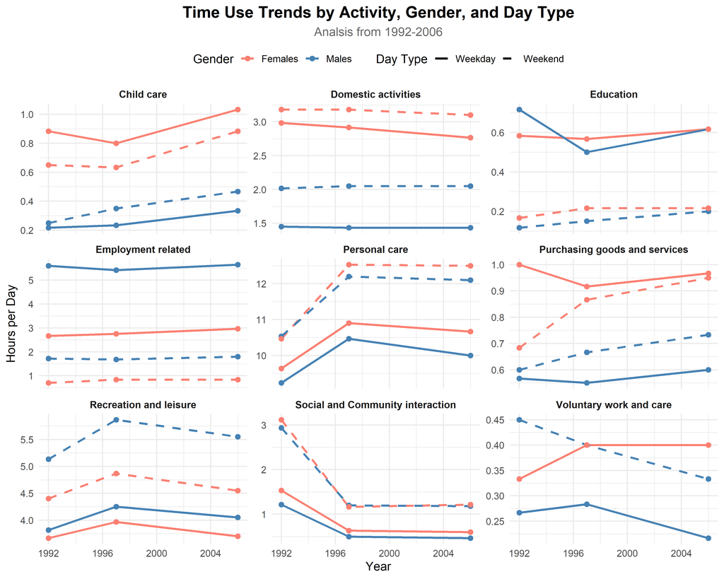

Figure 7

```r
ggplot(table2_data, aes(x = Year,
                       y = Time_Minutes / 60,
                       color = Gender,
                       linetype = DayType,
                       group = interaction(Gender, DayType))) +
  geom_line(linewidth = 1) +
  geom_point(size = 2) +
  facet_wrap(~ Activity, scales = "free_y", ncol = 3) +
  labs(
    title = "Time Use Trends by Activity, Gender, and Day Type",
    subtitle = "Analsis from 1992-2006",
    x = "Year",
    y = "Hours per Day",
    color = "Gender",
    linetype = "Day Type"
  ) +
  scale_color_manual(values = c("Males" = "steelblue", "Females" = "salmon")) +
  scale_linetype_manual(values = c("Weekday" = "solid", "Weekend" = "dashed")) +
  theme_minimal(base_size = 12) +
  theme(
    plot.title = element_text(hjust = 0.5, face = "bold", size = 16),
    plot.subtitle = element_text(hjust = 0.5, color = "gray40"),
    strip.text = element_text(face = "bold", size = 10),
    legend.position = "top"
  )
```

```r
table2_total <- table2_data %>%
  group_by(Activity, Year, DayType) %>%
  summarize(Time_Minutes = mean(Time_Minutes, na.rm = TRUE)) %>%
  ungroup() %>%
  pivot_wider(names_from = Year, values_from = Time_Minutes, names_prefix = "Time_") %>%
  mutate(
    Time_1992_Hrs = round(Time_1992 / 60, 2),
    Time_1997_Hrs = round(Time_1997 / 60, 2),
    Time_2006_Hrs = round(Time_2006 / 60, 2),
    Change_92_97_Hrs = round(Time_1997_Hrs - Time_1992_Hrs, 2),
    Pct_Change_92_97 = round((Change_92_97_Hrs / Time_1992_Hrs) * 100, 2),
    Change_97_06_Hrs = round(Time_2006_Hrs - Time_1997_Hrs, 2),
    Pct_Change_97_06 = round((Change_97_06_Hrs / Time_1997_Hrs) * 100, 2),
    Change_92_06_Hrs = round(Time_2006_Hrs - Time_1992_Hrs, 2),
    Pct_Change_92_06 = round((Change_92_06_Hrs / Time_1992_Hrs) * 100, 2)
  ) %>%
  select(Activity, DayType, Time_1992_Hrs, Time_1997_Hrs, Time_2006_Hrs,
         Change_92_97_Hrs, Pct_Change_92_97,
         Change_97_06_Hrs, Pct_Change_97_06,
         Change_92_06_Hrs, Pct_Change_92_06) %>%
  arrange(DayType, desc(abs(Change_92_06_Hrs)))

kable(table2_total,
      caption = "Time Use Changes by Day Type Across Years (Total, Hours per Day)",
      booktabs = TRUE,
      col.names = c("Activity", "Day Type", "1992 (Hrs)", "1997 (Hrs)", "2006 (Hrs)",
                    "Change 92-97 (Hrs)", "% Change 92-97",
                    "Change 97-06 (Hrs)", "% Change 97-06",
                    "Change 92-06 (Hrs)", "% Change 92-06")) %>%
  kable_styling(bootstrap_options = c("striped", "hover"),
                full_width = FALSE)
```

Table 2

Time Use Changes by Day Type Across Years (Total, Hours per Day)

| Activity | Day Type | 1992 (Hrs) | 1997 (Hrs) | 2006 (Hrs) | Change 92-97 (Hrs) | % Change 92-97 | Change 97-06 (Hrs) | % Change 97-06 | Change 92-06 (Hrs) | % Change 92-06 |
| --- | --- | --- | --- | --- | --- | --- | --- | --- | --- | --- |
| Social and Community interaction | Weekday | 1.38 | 0.57 | 0.53 | -0.81 | -58.70 | -0.04 | -7.02 | -0.85 | -61.59 |
| Personal care | Weekday | 10.22 | 10.84 | 10.67 | 0.62 | 6.07 | -0.17 | -1.57 | 0.45 | 4.40 |
| Employment related | Weekday | 4.13 | 4.08 | 4.31 | -0.05 | -1.21 | 0.23 | 5.64 | 0.18 | 4.36 |
| Recreation and leisure | Weekday | 3.74 | 4.11 | 3.88 | 0.37 | 9.89 | -0.23 | -5.60 | 0.14 | 3.74 |
| Child care | Weekday | 0.55 | 0.52 | 0.68 | -0.03 | -5.45 | 0.16 | 30.77 | 0.13 | 23.64 |
| Domestic activities | Weekday | 2.22 | 2.17 | 2.10 | -0.05 | -2.25 | -0.07 | -3.23 | -0.12 | -5.41 |
| Education | Weekday | 0.65 | 0.53 | 0.62 | -0.12 | -18.46 | 0.09 | 16.98 | -0.03 | -4.62 |
| Voluntary work and care | Weekday | 0.30 | 0.34 | 0.31 | 0.04 | 13.33 | -0.03 | -8.82 | 0.01 | 3.33 |
| Purchasing goods and services | Weekday | 0.78 | 0.73 | 0.78 | -0.05 | -6.41 | 0.05 | 6.85 | 0.00 | 0.00 |
| Social and Community interaction | Weekend | 3.02 | 1.18 | 1.20 | -1.84 | -60.93 | 0.02 | 1.69 | -1.82 | -60.26 |
| Personal care | Weekend | 10.75 | 11.68 | 11.65 | 0.93 | 8.65 | -0.03 | -0.26 | 0.90 | 8.37 |
| Recreation and leisure | Weekend | 4.77 | 5.37 | 5.05 | 0.60 | 12.58 | -0.32 | -5.96 | 0.28 | 5.87 |
| Child care | Weekend | 0.45 | 0.49 | 0.68 | 0.04 | 8.89 | 0.19 | 38.78 | 0.23 | 51.11 |
| Purchasing goods and services | Weekend | 0.64 | 0.77 | 0.84 | 0.13 | 20.31 | 0.07 | 9.09 | 0.20 | 31.25 |
| Employment related | Weekend | 1.21 | 1.26 | 1.32 | 0.05 | 4.13 | 0.06 | 4.76 | 0.11 | 9.09 |
| Education | Weekend | 0.14 | 0.18 | 0.21 | 0.04 | 28.57 | 0.03 | 16.67 | 0.07 | 50.00 |
| Domestic activities | Weekend | 2.60 | 2.62 | 2.58 | 0.02 | 0.77 | -0.04 | -1.53 | -0.02 | -0.77 |
| Voluntary work and care | Weekend | 0.39 | 0.40 | 0.37 | 0.01 | 2.56 | -0.03 | -7.50 | -0.02 | -5.13 |

**Major Shifts: The Decline of Socializing and the Rise of Child Care**:

**How Weekdays and Weekends Changed**:

Analysis of the data from 1992 to 2006 shows that the way Australians spent their time changed, especially on weekends.

On weekdays, life is centered around work, with more time spent on it than on leisure. Specifically, men’s weekday work hours consistently exceeded five hours, while women’s averaged around three hours and showed a gradual increasing trend. This pattern reverses on weekends, when leisure time becomes much higher than work time. On both day types, men spend more time on both work and leisure than women do.

The biggest shifts happened on weekends. People used this time to catch up on personal life, spending more hours on personal care and enjoying more leisure, while child care time also grew significantly. The largest gender differences on weekends were in leisure and domestic work: men spent more time on leisure, while women spent much more time on domestic activities. This overall focus on personal and family life came at a cost, as time spent on social interaction dropped sharply by almost two hours.

In summary, between 1992 and 2006, Australians’ lives shifted. Weekends, once a key time for socializing with the community, became more focused on private life—caring for children, personal rest, and individual leisure. While gender roles with women doing more housework continued, the overall trend points to a society spending less time together in the community and more time focused on the home.

## Resources

The materials used for this report are:

Wickham H, Averick M, Bryan J, Chang W, McGowan LD, François R, Grolemund G, Hayes A, Henry L, Hester J, Kuhn M, Pedersen TL, Miller E, Bache SM, Müller K, Ooms J, Robinson D, Seidel DP, Spinu V, Takahashi K, Vaughan D, Wilke C, Woo K, Yutani H (2019). “Welcome to the tidyverse.” *Journal of Open Source Software*, *4*(43), 1686. [doi:10.21105/joss.01686](https://doi.org/10.21105/joss.01686).

Firke S (2024). *janitor: Simple Tools for Examining and Cleaning Dirty Data*. R package version 2.2.1, https://CRAN.R-project.org/package=janitor.

Wickham H, Hester J, Bryan J (2024). *readr: Read Rectangular Text Data*. R package version 2.1.5, https://CRAN.R-project.org/package=readr.

Garrett Grolemund, Hadley Wickham (2011). Dates and Times Made Easy with lubridate. Journal of Statistical Software, 40(3), 1-25. URL https://www.jstatsoft.org/v40/i03/.

Wickham H, Bryan J (2025). *readxl: Read Excel Files*. R package version 1.4.5, https://CRAN.R-project.org/package=readxl.

Müller K (2020). *here: A Simpler Way to Find Your Files*. R package version 1.0.1, https://CRAN.R-project.org/package=here.

Mark P. J. van der Loo, Edwin de Jonge (2021). Data Validation Infrastructure for R. Journal of Statistical Software, 97(10), 1-31. doi:10.18637/jss.v097.i10

Zhu H (2024). *kableExtra: Construct Complex Table with ‘kable’ and Pipe Syntax*. R package version 1.4.0, https://CRAN.R-project.org/package=kableExtra.

The links to my use of ChatGPT for help on this assignment are:

- https://chatgpt.com/share/68d2bab9-cc98-8000-b022-149114129bcd helped to categorize the active vs passive leisure.
- https://chatgpt.com/share/68d384a0-75b8-8000-8322-ab7d6b015052 helped to tackle multi-level header as one header
- https://chatgpt.com/share/68d39232-b46c-8000-b83f-7251866aff12 helped to judge RSE different levels.